## 4.3 Discussion Question

# A double robust estimator helps eliminate model misspecification bias, by ensuring that the analysis still works even if one of the outcome or propensity models is still correct. TMLE is able to address missing outcomes and is more efficient by establishing the smallest possible asymptomic variance of any possible estimator. TMLE also does not rely on parametric assumptions, and in some ways can be consider semiparametric. By only relying on no unobserved confounding & positivity asumptions, TMLE is able to provide two chances of having the correct outcome or propensity model to address confounding.

```r
data_obs_ltmle <-
 heart_disease %>%
  mutate(Y = heart_disease$mortality,
         A_2 = heart_disease$blood_pressure_medication_2) %>%
  rename(A = blood_pressure_medication)
```

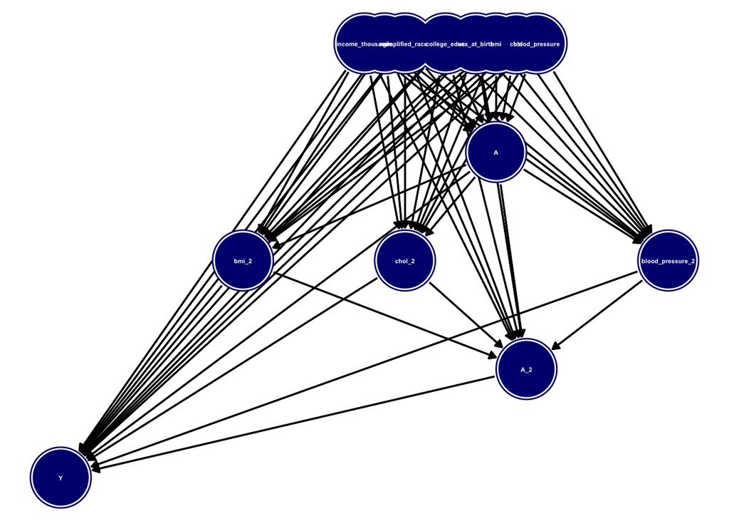

```r
# Create a DAG using dagify
# ----------
dag_ltmle <- dagify(
      Y ~ A + A_2 + sex_at_birth + age + simplified_race + college_educ + income_thousands + bmi + chol + blood_pressure +  bmi_2 +            chol_2 + blood_pressure_2 ,
       A ~ sex_at_birth + age + simplified_race + college_educ + income_thousands + bmi + chol + blood_pressure,
        A_2 ~ A + sex_at_birth + age + simplified_race + college_educ + income_thousands + bmi_2 + chol_2 + blood_pressure_2,
      bmi_2 ~ A + sex_at_birth + age + simplified_race + college_educ + income_thousands + bmi + chol + blood_pressure,
       chol_2 ~ A + sex_at_birth + age + simplified_race + college_educ + income_thousands + bmi + chol + blood_pressure,
      blood_pressure_2 ~ A + sex_at_birth + age + simplified_race + college_educ + income_thousands + bmi + chol +blood_pressure,
     exposure = "A_2",
       outcome = "Y"
      )
 ggdag(dag_ltmle, layout = "sugiyama") +
  geom_dag_edges_link() +
  geom_dag_node(size = 19.5, color = "navyblue") +
  geom_dag_text(color = "white", size = 1.5) +
  theme_void()
```

## In this DAG we can see the temporal order of variables collected at different time points. This DAG shows how the Baseline covariates impact A ( treatment selected at time point 1) and Y ( mortality). The BMI, Cholestrol, and Blood pressure collected at time point 2 are impacted by the Baseline Covarites as well as the treatment selected at time point 1. The treatment selected at time point 2 (A_2), is influenced by prior treatment at time period 1 (A), baseline covariates, bmi_2, chol_2, blood_pressure_2. Lastly, when using longitudal TMLE we see that our Y (mortality) predictions are influenced by all these time varying confounders, baseline, treatment selection at both time periods. Temporal order can be shown with W1,W2, W3,W4, W5, W6, W7, W8, A, W9, W10, W11, A_2, Y with W’s indicating the different covariates measured

```r
# process data
# ----------
data_obs_ltmle <-
 heart_disease %>%
  mutate(Y = heart_disease$mortality) %>%
  rename(A = blood_pressure_medication) %>%
  # need to specify W1, W2, etc
  rename ( W1 = bmi, W2 = chol, W3 = blood_pressure, W4 = sex_at_birth, W5 = age, W6 = simplified_race, W7 = college_educ, W8 = income_thousands) %>%
  select(W1, W2, W3,W4, W5, W6, W7, W8, A, Y)
```

```r
# implement ltmle  Naive Model. Without Sl. Library and without Lnodes (timevarying covariates)
# ----------
set.seed(1000)
result <- ltmle(data_obs_ltmle, # dataset
                Anodes = "A",   # vector that shows treatment
                Ynodes = "Y",   # vector that shows outcome
                abar = list(1,0))
```

```
## Qform not specified, using defaults:
```

```
## formula for Y:
```

```
## Q.kplus1 ~ W1 + W2 + W3 + W4 + W5 + W6 + W7 + W8 + A
```

```
## gform not specified, using defaults:
```

```
## formula for A:
```

```
## A ~ W1 + W2 + W3 + W4 + W5 + W6 + W7 + W8
```

```
## Estimate of time to completion: < 1 minute
```

```r
# view
summary(result)
```

```
## Estimator:  tmle
## Call:
## ltmle(data = data_obs_ltmle, Anodes = "A", Ynodes = "Y", abar = list(1,
##     0))
##
## Treatment Estimate:
##    Parameter Estimate:  0.20417
##     Estimated Std Err:  0.011418
##               p-value:  <2e-16
##     95% Conf Interval: (0.18179, 0.22655)
##
## Control Estimate:
##    Parameter Estimate:  0.56615
##     Estimated Std Err:  0.0054108
##               p-value:  <2e-16
##     95% Conf Interval: (0.55555, 0.57676)
##
## Additive Treatment Effect:
##    Parameter Estimate:  -0.36198
##     Estimated Std Err:  0.012579
##               p-value:  <2e-16
##     95% Conf Interval: (-0.38663, -0.33732)
##
## Relative Risk:
##    Parameter Estimate:  0.36063
##   Est Std Err log(RR):  0.056626
##               p-value:  <2e-16
##     95% Conf Interval: (0.32275, 0.40296)
##
## Odds Ratio:
##    Parameter Estimate:  0.1966
##   Est Std Err log(OR):  0.073401
##               p-value:  <2e-16
##     95% Conf Interval: (0.17026, 0.22702)
```

## According to these results,the control group ( i.e those that did not take blood pressure medication) is approx. 56.6% mortality rate while the treated group had a 20% mortatility rate. The additive treatment effect(ATE) shows an reduction in mortality rate of 36.2% percentage points if one was in the treated group compared to untreated group (i.e control). The Pvalue and CI show that this was a statistically significant reduction in mortality rate outcomes for those that actally took the blood presure medication. However this is a naive model not addressing the time varying confounders.

```r
# process data
# ----------
data_obs_ltmle <-
 heart_disease %>%
  mutate(Y = heart_disease$mortality) %>%
  rename(A = blood_pressure_medication,
         A_2 = blood_pressure_medication_2 ,
         W1 = bmi, W2 = chol, W3 = blood_pressure,
         W4 = sex_at_birth, W5 = age, W6 = simplified_race, W7 = college_educ, W8 = income_thousands,
         W9 = bmi_2, W10 = chol_2, W11 = blood_pressure_2) %>% ## time varying covaraites
  select(W1, W2, W3,W4, W5, W6, W7, W8, A, W9, W10, W11, A_2, Y)
```

```r
# identify number of cores to use
library(future)
n_cores <- availableCores() - 1 # maybe 2 cores instead?

# plan separate session
  plan(multisession,
     workers = n_cores)

# set seed - option will set same seed across multiple cores
set.seed(44, "L'Ecuyer-CMRG")

# cross-validation across cores
# ----------
cv_sl = CV.SuperLearner(Y = y_train,
                        X = x_train,
                        family = binomial(),      #
                        V = 20,                   # default fold recommendation for Superlearner
                        SL.library = c("SL.glm","SL.glmnet","SL.mean","SL.bayesglm","SL.rpart"))

summary(cv_sl)
```

```
##
## Call:
## CV.SuperLearner(Y = y_train, X = x_train, V = 20, family = binomial(), SL.library = c("SL.glm",
##     "SL.glmnet", "SL.mean", "SL.bayesglm", "SL.rpart"))
##
## Risk is based on: Mean Squared Error
##
## All risk estimates are based on V =  20
##
##        Algorithm     Ave         se     Min     Max
##    Super Learner 0.22829 0.00127630 0.21722 0.23980
##      Discrete SL 0.22821 0.00130592 0.21712 0.23998
##       SL.glm_All 0.23464 0.00132745 0.22097 0.24432
##    SL.glmnet_All 0.23446 0.00127579 0.22168 0.24384
##      SL.mean_All 0.24962 0.00024827 0.24769 0.25222
##  SL.bayesglm_All 0.23464 0.00132609 0.22098 0.24431
##     SL.rpart_All 0.22821 0.00130592 0.21712 0.23998
```

```r
# implement ltmle Treatment effect of treated
# ----------
set.seed(1000)
results_2 <-ltmle(data_obs_ltmle,
      Anodes=c("A", "A_2"),## treatment indicator in Anodes vector. E[Y| A=1 , A_2=1]
     Lnodes= c("W9","W10", "W11"),
      Ynodes="Y",            # outcome
      abar = list(treated = c(1,1), control = c(0,0)),  # treatment indicator in Anodes vector. E[Y| A=1 , A_2=1]
      SL.library = c("SL.glm","SL.mean","SL.bayesglm","SL.rpart"))
```

```
## Qform not specified, using defaults:
```

```
## formula for W9:
```

```
## Q.kplus1 ~ W1 + W2 + W3 + W4 + W5 + W6 + W7 + W8 + A
```

```
## formula for Y:
```

```
## Q.kplus1 ~ W1 + W2 + W3 + W4 + W5 + W6 + W7 + W8 + A + W9 + W10 +     W11 + A_2
```

```
## gform not specified, using defaults:
```

```
## formula for A:
```

```
## A ~ W1 + W2 + W3 + W4 + W5 + W6 + W7 + W8
```

```
## formula for A_2:
```

```
## A_2 ~ W1 + W2 + W3 + W4 + W5 + W6 + W7 + W8 + A + W9 + W10 +     W11
```

```
## Estimate of time to completion: 1 minute
```

```r
summary(results_2)
```

```
## Estimator:  tmle
## Call:
## ltmle(data = data_obs_ltmle, Anodes = c("A", "A_2"), Lnodes = c("W9",
##     "W10", "W11"), Ynodes = "Y", abar = list(treated = c(1, 1),
##     control = c(0, 0)), SL.library = c("SL.glm", "SL.mean", "SL.bayesglm",
##     "SL.rpart"))
##
## Treatment Estimate:
##    Parameter Estimate:  0.19785
##     Estimated Std Err:  0.030289
##               p-value:  6.487e-11
##     95% Conf Interval: (0.13849, 0.25722)
##
## Control Estimate:
##    Parameter Estimate:  0.56727
##     Estimated Std Err:  0.0058372
##               p-value:  <2e-16
##     95% Conf Interval: (0.55583, 0.57871)
##
## Additive Treatment Effect:
##    Parameter Estimate:  -0.36942
##     Estimated Std Err:  0.030847
##               p-value:  <2e-16
##     95% Conf Interval: (-0.42988, -0.30896)
##
## Relative Risk:
##    Parameter Estimate:  0.34878
##   Est Std Err log(RR):  0.15344
##               p-value:  6.654e-12
##     95% Conf Interval: (0.25819, 0.47114)
##
## Odds Ratio:
##    Parameter Estimate:  0.18815
##   Est Std Err log(OR):  0.19233
##               p-value:  <2e-16
##     95% Conf Interval: (0.12906, 0.27429)
```

## According to these results,the control group ( i.e those that did not take blood pressure medication) is approx. 56.7% mortality rate while the treated group had a 19.8% mortatility rate. The additive treatment effect(ATE) shows an reduction in mortality rate of 36.9% percentage points if one was in the treated group compared to untreated group (i.e control). The Pvalue and CI show that this was a statistically significant reduction in mortality rate outcomes for those that actally took the blood presure medication. While the NAIVE model results are somewhat similar, this output is different because accurately addresses the time varying confounders and both the treatments provided at time point 1 and 2. Differences seen in estimates are minimal

## 5.3 Discussion questions

# Time dependent confounding variables we should be worried about in include changing bmi, blood pressure, and cholestrol. We worry about these type of time varying confounders because they are impacted by prior treatment in time point 1 (A) and baseline covariates ( W1-W8). These type of variables also impact future treatment selection(A-2) and predicted outcomes (Y). This is different than a time varying running variable such as age, because while age does change throughout time impacting the overall outcome (Y) and baseline variables (W1-8) it is not technically impacted by treatment at Time 1 (A). Treatment does not determine what your age, this variables naturally increases with time.